# R Notebook

```r
library(tidyverse)
library(lubridate)
library(nycflights13)
```

What happens if you parse a string that contains invalid dates? for example, no month has 50 days

```r
ymd(2000-01-50)
```

```
All formats failed to parse. No formats found.
```

```
[1] NA
```

fails to parse

ymd(c(“2010-10-10”, “bananas”))

What does the tzone argument to today() do? Why is it important?

```r
today(tzone = "UTC")
```

```
[1] "2019-03-16"
```

applies time zone to today, it is important because depending on where you are in the world, it could be the next day or something

Use the appropriate lubridate function to parse each of the following dates:

```r
d1 <- "January 1, 2010"
d2 <- "2015-Mar-07"
d3 <- "06-Jun-2017"
d4 <- c("August 19 (2015)", "July 1 (2015)")
d5 <- "12/30/14" # Dec 30, 2014
```

```r
mdy(d1)
```

```
[1] "2010-01-01"
```

```r
ymd(d2)
```

```
[1] "2015-03-07"
```

```r
dmy(d3)
```

```
[1] "2017-06-06"
```

```r
mdy(d4)
```

```
[1] "2015-08-19" "2015-07-01"
```

```r
mdy(d5)
```

```
[1] "2014-12-30"
```

16.3.4 How does the distribution of flight times within a day change over the course of the year?

| origin | dest | dep_delay | arr_delay | dep_time | sched_dep_time | arr_time | sched_arr_time | air_time |
| --- | --- | --- | --- | --- | --- | --- | --- | --- |
| EWR | IAH | 2 | 11 | 2013-01-01 05:17:00 | 2013-01-01 05:15:00 | 2013-01-01 08:30:00 | 2013-01-01 08:19:00 | 227 |
| LGA | IAH | 4 | 20 | 2013-01-01 05:33:00 | 2013-01-01 05:29:00 | 2013-01-01 08:50:00 | 2013-01-01 08:30:00 | 227 |
| JFK | MIA | 2 | 33 | 2013-01-01 05:42:00 | 2013-01-01 05:40:00 | 2013-01-01 09:23:00 | 2013-01-01 08:50:00 | 160 |
| JFK | BQN | -1 | -18 | 2013-01-01 05:44:00 | 2013-01-01 05:45:00 | 2013-01-01 10:04:00 | 2013-01-01 10:22:00 | 183 |
| LGA | ATL | -6 | -25 | 2013-01-01 05:54:00 | 2013-01-01 06:00:00 | 2013-01-01 08:12:00 | 2013-01-01 08:37:00 | 116 |
| EWR | ORD | -4 | 12 | 2013-01-01 05:54:00 | 2013-01-01 05:58:00 | 2013-01-01 07:40:00 | 2013-01-01 07:28:00 | 150 |
| EWR | FLL | -5 | 19 | 2013-01-01 05:55:00 | 2013-01-01 06:00:00 | 2013-01-01 09:13:00 | 2013-01-01 08:54:00 | 158 |
| LGA | IAD | -3 | -14 | 2013-01-01 05:57:00 | 2013-01-01 06:00:00 | 2013-01-01 07:09:00 | 2013-01-01 07:23:00 | 53 |
| JFK | MCO | -3 | -8 | 2013-01-01 05:57:00 | 2013-01-01 06:00:00 | 2013-01-01 08:38:00 | 2013-01-01 08:46:00 | 140 |
| LGA | ORD | -2 | 8 | 2013-01-01 05:58:00 | 2013-01-01 06:00:00 | 2013-01-01 07:53:00 | 2013-01-01 07:45:00 | 138 |

[output cut: 990 more lines]

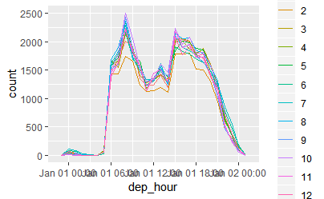

Compare dep_time, sched_dep_time and dep_delay. Are they consistent? Explain your findings.

| dep_time | sched_dep_time | dep_delay | dep_time1 |
| --- | --- | --- | --- |
| 2013-01-01 08:48:00 | 2013-01-01 18:35:00 | 853 | 2013-01-02 08:48:00 |
| 2013-01-02 00:42:00 | 2013-01-02 23:59:00 | 43 | 2013-01-03 00:42:00 |
| 2013-01-02 01:26:00 | 2013-01-02 22:50:00 | 156 | 2013-01-03 01:26:00 |
| 2013-01-03 00:32:00 | 2013-01-03 23:59:00 | 33 | 2013-01-04 00:32:00 |
| 2013-01-03 00:50:00 | 2013-01-03 21:45:00 | 185 | 2013-01-04 00:50:00 |
| 2013-01-03 02:35:00 | 2013-01-03 23:59:00 | 156 | 2013-01-04 02:35:00 |
| 2013-01-04 00:25:00 | 2013-01-04 23:59:00 | 26 | 2013-01-05 00:25:00 |
| 2013-01-04 01:06:00 | 2013-01-04 22:45:00 | 141 | 2013-01-05 01:06:00 |
| 2013-01-05 00:14:00 | 2013-01-05 23:59:00 | 15 | 2013-01-06 00:14:00 |
| 2013-01-05 00:37:00 | 2013-01-05 22:30:00 | 127 | 2013-01-06 00:37:00 |

[output cut: 990 more lines]

not all consistent, some have dep time that is the next day following sched dep time

Compare air_time with the duration between the departure and arrival. Explain your findings. (Hint: consider the location of the airport.)

| origin | dest | flighttime | airtime_min | diff |
| --- | --- | --- | --- | --- |
| EWR | IAH | 193 | 227 | -34 |
| LGA | IAH | 197 | 227 | -30 |
| JFK | MIA | 221 | 160 | 61 |
| JFK | BQN | 260 | 183 | 77 |
| LGA | ATL | 138 | 116 | 22 |
| EWR | ORD | 106 | 150 | -44 |
| EWR | FLL | 198 | 158 | 40 |
| LGA | IAD | 72 | 53 | 19 |
| JFK | MCO | 161 | 140 | 21 |
| LGA | ORD | 115 | 138 | -23 |

[output cut: 990 more lines]

How does the average delay time change over the course of a day? Should you use dep_time or sched_dep_time? Why?

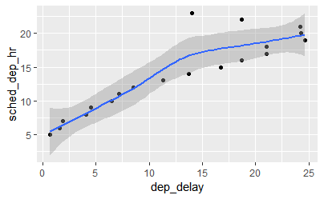

On what day of the week should you leave if you want to minimise the chance of a delay? find the lowest avg delay per day, making days, grouping days together and then average

| daysofthewk | dep_delay | arr_delay |
| --- | --- | --- |
| 1 | 11.495974 | 4.820024 |
| 2 | 14.734220 | 9.653739 |
| 3 | 10.591532 | 5.388526 |
| 4 | 11.699198 | 7.051119 |
| 5 | 16.064837 | 11.740819 |
| 6 | 14.660643 | 9.070120 |
| 7 | 7.620118 | -1.448828 |

What makes the distribution of diamonds$carat and flights$sched_dep_time similar?

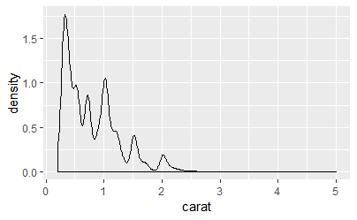

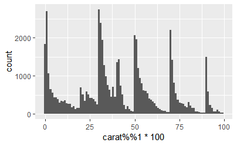

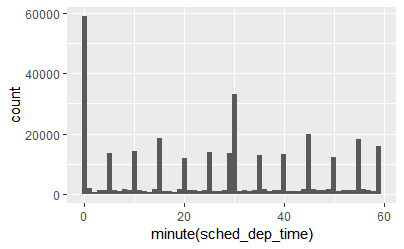

Confirm my hypothesis that the early departures of flights in minutes 20-30 and 50-60 are caused by scheduled flights that leave early. Hint: create a binary variable that tells you whether or not a flight was delayed.

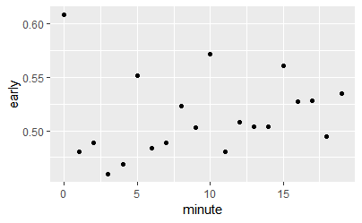

16.4.5 Why is there months() but no dmonths()?

```r
months()
```

cuz every month has a different number of days

Explain days(overnight * 1) to someone who has just started learning R. How does it work? takes the date and checks whether or not it is overnight, if it is then it multiplies it by 1 else 0 and no day is added.

Create a vector of dates giving the first day of every month in 2015. Create a vector of dates giving the first day of every month in the current year.

```r
exdates
```

[output not shown]

```r
floor_date(today(), unit = 'year')+months(0:11)
```

```
 [1] "2019-01-01" "2019-02-01" "2019-03-01"
 [4] "2019-04-01" "2019-05-01" "2019-06-01"
 [7] "2019-07-01" "2019-08-01" "2019-09-01"
[10] "2019-10-01" "2019-11-01" "2019-12-01"
```

Write a function that given your birthday (as a date), returns how old you are in years.

Why can’t (today() %–% (today() + years(1)) / months(1) work?